# FigureYa130SVM_step12

Yufang Wang, Dongqiang Zeng

2025-5-20

# Academic Citation

If you use this code in your work or research, we kindly request that you cite our publication:

Xiaofan Lu, et al. (2025). FigureYa: A Standardized Visualization Framework for Enhancing Biomedical Data Interpretation and Research Efficiency. iMetaMed. https://doi.org/10.1002/imm3.70005

## Requirement Description

筛选差异基因后，用cox regression、SVM-RFE和FW-SVM算法进一步筛选有预后意义的基因，组成基因甲基化位点或表达的signature。 After filtering differential genes, use Cox regression, SVM-RFE, and FW-SVM algorithms to further select prognostic genes to construct a gene methylation site or expression signature.

[figure not shown]

出自https://onlinelibrary.wiley.com/doi/full/10.1111/jcmm.14231 Source: https://onlinelibrary.wiley.com/doi/full/10.1111/jcmm.14231

主要分四步来实现，其中前两步在R里实现，后两步在python里实现，运行完本文档FigureYa130coxSVM_step12.Rmd之后，运行FigureYa130coxSVM_step34.ipynb： The process consists of four main steps. The first two steps are implemented in R, and the latter two in Python. After running this document FigureYa130coxSVM_step12.Rmd, proceed with FigureYa130coxSVM_step34.ipynb:

- 第一步，正常人与癌症患者差异化比较 Step 1: Differential analysis between normal and cancer samples
- 第二步，寻找相关矩阵，并生成下游数据 Step 2: Identify correlation matrix and generate downstream data
- 第三步，REF-SVM寻找合适的特征范围 Step 3: Use REF-SVM to find the optimal feature range
- 第四步，FW-SVM进一步喜欢特征数目 Step 4: Use FW-SVM to further select feature numbers

## Environment Setup

```r
source("install_dependencies.R")
```

```
## Starting R package installation...
## ===========================================
## Installing basic utilities...
## ✅ Package already installed: BiocManager
## ✅ Package already installed: remotes
##
## Installing CRAN packages...
## ✅ Package already installed: RColorBrewer
## ✅ Package already installed: survival
## ✅ Package already installed: tidyverse
## ✅ Package already installed: ggplot2
## ✅ Package already installed: dplyr
##
## Setting up methylation analysis packages...
## ✅ ChAMP package already installed
##
## Installing other Bioconductor packages...
## ✅ Package already installed: minfi
## ✅ Package already installed: limma
##
## ===========================================
## Package installation completed!
##
## Final package status:
## ✅ RColorBrewer
## ✅ survival
## ✅ tidyverse
## ✅ minfi
## ✅ ChAMP
##
## ✅ All packages installed successfully!
## You can now run your R scripts in this directory.
```

```r
library(tidyverse)
library(ChAMP)
```

```
##
##
## locfit 1.5-9.12   2025-03-05
##
##
## Setting options('download.file.method.GEOquery'='auto')
## Setting options('GEOquery.inmemory.gpl'=FALSE)
```

```
## No methods found in package 'RSQLite' for request: 'dbListFields' when loading 'lumi'
```

[output not shown]

```r
library(minfi)
library(RColorBrewer)
library(survival)

Sys.setenv(LANGUAGE = "en") #显示英文报错信息 Display error messages in English
options(stringsAsFactors = FALSE) #禁止chr转成factor Prevent automatic conversion of character to factor
```

## Input File Download

从XENAhttps://xenabrowser.net/datapages/下载两类数据，以GDC TCGA Liver Cancer (LIHC) (14 datasets)为例： Download two types of data from XENA using the GDC TCGA Liver Cancer (LIHC) (14 datasets) as an example:

- 甲基化数据DNA methylation - Methylation450k，地址：https://xenabrowser.net/datapages/?dataset=TCGA-LIHC.methylation450.tsv&host=https%3A%2F%2Fgdc.xenahubs.net&removeHub=https%3A%2F%2Fxena.treehouse.gi.ucsc.edu%3A443，下载链接：https://gdc.xenahubs.net/download/TCGA-LIHC.methylation450.tsv.gz
- DNA methylation data - Methylation450k, location:https://xenabrowser.net/datapages/?dataset=TCGA-LIHC.methylation450.tsv&host=https%3A%2F%2Fgdc.xenahubs.net&removeHub=https%3A%2F%2Fxena.treehouse.gi.ucsc.edu%3A443, Download link:https://gdc.xenahubs.net/download/TCGA-LIHC.methylation450.tsv.gz
- 生存数据phenotype, survival data (n=463) GDC Hub，https://xenabrowser.net/datapages/?dataset=TCGA-LIHC.survival.tsv&host=https%3A%2F%2Fgdc.xenahubs.net&removeHub=https%3A%2F%2Fxena.treehouse.gi.ucsc.edu%3A443，下载链接：https://gdc.xenahubs.net/download/TCGA-LIHC.survival.tsv.gz
- Survival data: phenotype, survival data (n=463) from GDC Hub, https://xenabrowser.net/datapages/?dataset=TCGA-LIHC.survival.tsv&host=https%3A%2F%2Fgdc.xenahubs.net&removeHub=https%3A%2F%2Fxena.treehouse.gi.ucsc.edu%3A443, Download link: https://gdc.xenahubs.net/download/TCGA-LIHC.survival.tsv.gz

```r
# 读入甲基化数据
# Read methylation data
nor_methy <- read_tsv("TCGA-LIHC.methylation450.tsv")
nor_methy <- column_to_rownames(nor_methy, var = "Composite Element REF")
nor_methy <- na.omit(nor_methy)

#########################
nor_methy[1:5,1:5]
```

```
##            TCGA-DD-A73D-01A TCGA-G3-A5SK-01A TCGA-DD-A1EL-11A TCGA-DD-AAD8-01A
## cg00000108       0.11713712       0.42874771       0.59005600       0.16431493
## cg00000236       0.94305014       0.91880630       0.85326680       0.85561589
## cg00000292       0.65738158       0.67620749       0.81119031       0.71972908
## cg00000363       0.85190749       0.75191282       0.61515442       0.64232441
## cg00000622       0.01452019       0.01425615       0.01370397       0.01154347
##            TCGA-WX-AA47-01A
## cg00000108       0.25936862
## cg00000236       0.93187399
## cg00000292       0.79250931
## cg00000363       0.80029544
## cg00000622       0.01509556
```

```r
dim(nor_methy)
```

```
## [1] 300641    430
```

```r
##########################

# 读入生存数据
# Read survival data
sur_data <- read.csv("TCGA-LIHC.survival.tsv",sep = "\t",header = T)
head(sur_data)
```

```
##             sample OS    X_PATIENT OS.time
## 1 TCGA-FV-A495-11A  0 TCGA-FV-A495       1
## 2 TCGA-FV-A495-01A  0 TCGA-FV-A495       1
## 3 TCGA-ED-A7PZ-01A  0 TCGA-ED-A7PZ       6
## 4 TCGA-ED-A97K-01A  0 TCGA-ED-A97K       6
## 5 TCGA-ED-A7PX-01A  0 TCGA-ED-A7PX       6
## 6 TCGA-BC-A3KF-01A  0 TCGA-BC-A3KF       8
```

```r
colnames(sur_data) <- c("sample", "OS_status", "ID", "OS_time")
sur_data <- sur_data[!is.na(sur_data$OS_time),]
sur_data <- sur_data[!is.na(sur_data$OS_status),]
sur_data <- sur_data[,c("ID","OS_time","OS_status")]
#去除急性进展患者对生存分析的影响
# Remove rapidly progressing patients to avoid bias in survival analysis
sur_data <- sur_data[sur_data$OS_time>30,]
dim(sur_data)
```

```
## [1] 435   3
```

```r
###################################
sur_data$OS_time <- sur_data$OS_time/30
head(sur_data)
```

```
##              ID  OS_time OS_status
## 29 TCGA-GJ-A6C0 1.033333         1
## 30 TCGA-GJ-A6C0 1.033333         1
## 31 TCGA-BC-A10Z 1.133333         1
## 32 TCGA-BC-A10Z 1.133333         1
## 33 TCGA-2Y-A9HA 1.200000         1
## 34 TCGA-DD-A73E 1.466667         0
```

```r
####################################
```

## 第一步，正常人与癌症患者差异化比较

## Step 1: Differential analysis between normal and tumor samples

```r
# 根据TCGA的barcode构建癌和癌旁的分类信号
# Use TCGA barcode to classify tumor and normal samples
sampleid <- colnames(nor_methy)
pdata <- data.frame(ID = sampleid,tissue_type = substring(sampleid,14,16))
head(pdata)
```

```
##                 ID tissue_type
## 1 TCGA-DD-A73D-01A         01A
## 2 TCGA-G3-A5SK-01A         01A
## 3 TCGA-DD-A1EL-11A         11A
## 4 TCGA-DD-AAD8-01A         01A
## 5 TCGA-WX-AA47-01A         01A
## 6 TCGA-DD-A1EL-01A         01A
```

```r
summary(as.factor(pdata$tissue_type))
```

```
## 01A 01B 02A 02B 11A
## 375   2   2   1  50
```

```r
pdata <- pdata[!pdata$tissue_type=="01B",]
pdata <- pdata[!pdata$tissue_type=="02B",]
pdata$group <- ifelse(pdata$tissue_type=="11A","normal","tumor")
summary(as.factor(pdata$group))
```

```
## normal  tumor
##     50    377
```

```r
##########################
nor_methy <- nor_methy[,colnames(nor_methy)%in%pdata$ID]
dim(nor_methy)
```

```
## [1] 300641    427
```

```r
pdata <- pdata[match(colnames(nor_methy),pdata$ID),]
data.frame(pdata$ID,colnames(nor_methy))
```

```
##             pdata.ID colnames.nor_methy.
## 1   TCGA-DD-A73D-01A    TCGA-DD-A73D-01A
## 2   TCGA-G3-A5SK-01A    TCGA-G3-A5SK-01A
## 3   TCGA-DD-A1EL-11A    TCGA-DD-A1EL-11A
## 4   TCGA-DD-AAD8-01A    TCGA-DD-AAD8-01A
## 5   TCGA-WX-AA47-01A    TCGA-WX-AA47-01A
## 6   TCGA-DD-A1EL-01A    TCGA-DD-A1EL-01A
## 7   TCGA-G3-A3CH-01A    TCGA-G3-A3CH-01A
## 8   TCGA-ZP-A9CZ-01A    TCGA-ZP-A9CZ-01A
## 9   TCGA-ZS-A9CG-01A    TCGA-ZS-A9CG-01A
## 10  TCGA-BC-A10W-11A    TCGA-BC-A10W-11A
## 11  TCGA-RC-A6M4-01A    TCGA-RC-A6M4-01A
## 12  TCGA-DD-A39Z-01A    TCGA-DD-A39Z-01A
## 13  TCGA-DD-AACD-01A    TCGA-DD-AACD-01A
## 14  TCGA-ZP-A9D1-01A    TCGA-ZP-A9D1-01A
```

[output cut: 413 more lines]

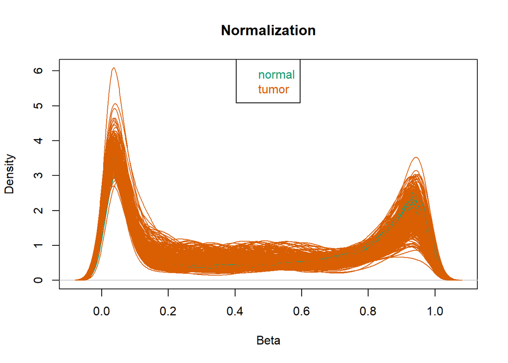

```r
##########################
save(nor_methy,pdata,file = "input.RData")

#查看数据标准化的结果
# Visualize normalization result
##########################
# visualise what the data looks like before and after normalisation
densityPlot(as.matrix(nor_methy), sampGroups=pdata$group,main="Normalization", legend=FALSE)
legend("top", legend = levels(factor(pdata$group)),
       text.col=brewer.pal(8,"Dark2"))
```

```r
#从结果来看UCSC这个标准化做的并不好
# The UCSC normalization seems suboptimal
#########################

# 正常人与癌症患者差异化比较
# Identify differential methylation between tumor and normal
#' @find-Differential-Methylation-Probes
myDMP <- champ.DMP(beta = nor_methy,pheno=pdata$group)
```

```
## [===========================]
```

```
## [<<<<< ChAMP.DMP START >>>>>]
```

```
## !!! Important !!! New Modification has been made on champ.DMP():
```

```
##     (1): In this version champ.DMP() if your pheno parameter contains more than two groups of phenotypes, champ.DMP() would do pairewise differential methylated analysis between each pair of them. But you can also specify compare.group to only do comparasion between any two of them.
```

```
##     (2): champ.DMP() now support numeric as pheno, and will do linear regression on them. So covariates like age could be inputted in this function. You need to make sure your inputted "pheno" parameter is "numeric" type.
```

```
##
## [ Section 1:  Check Input Pheno Start ]
```

```
##   You pheno is character type.
```

```
##     Your pheno information contains following groups. >>
```

```
##     <tumor>:377 samples.
```

```
##     <normal>:50 samples.
```

```
##     [The power of statistics analysis on groups contain very few samples may not strong.]
```

```
##     pheno contains only 2 phenotypes
```

```
##     compare.group parameter is NULL, two pheno types will be added into Compare List.
```

```
##     tumor_to_normal compare group : tumor, normal
```

```
##
## [ Section 1:  Check Input Pheno Done ]
```

```
##
## [ Section 2:  Find Differential Methylated CpGs Start ]
```

```
##   Start to Compare : tumor, normal
```

```
##   Contrast Matrix
```

```
##          Contrasts
## Levels    ptumor-pnormal
##   pnormal             -1
##   ptumor               1
```

```
##   You have found 178299 significant MVPs with a BH adjusted P-value below 0.05.
```

```
##   Calculate DMP for tumor and normal done.
```

```
##
## [ Section 2:  Find Numeric Vector Related CpGs Done ]
```

```
##
## [ Section 3:  Match Annotation Start ]
```

```
##
## [ Section 3:  Match Annotation Done ]
```

```
## [<<<<<< ChAMP.DMP END >>>>>>]
```

```
## [===========================]
```

```
## [You may want to process DMP.GUI() or champ.GSEA() next.]
```

```r
head(myDMP[[1]])
```

```
##                      logFC    AveExpr         t       P.Value     adj.P.Val
## cg13814654      0.32067228 0.89376828  33.11274 7.086434e-120 2.130473e-114
## cg13053914      0.18126583 0.93504098  30.51945 2.964839e-109 4.456760e-104
## cg26915558      0.35068300 0.87495191  29.47016 7.387096e-105 7.402880e-100
## cg13894813      0.32222905 0.87171264  28.64820 2.240888e-101  1.684257e-96
## cg07688052      0.29984515 0.88505305  26.63631  1.011621e-92  6.082696e-88
## ch.10.2610459F -0.08665431 0.05321996 -26.22370  6.330597e-91  3.009038e-86
##                       B  tumor_AVG normal_AVG   deltaBeta CHR   MAPINFO Strand
## cg13814654     262.9558 0.93131773  0.6106455 -0.32067228   2 101666894      R
## cg13053914     238.6668 0.95626649  0.7750007 -0.18126583   7  75511260      R
## cg26915558     228.6078 0.91601550  0.5653325 -0.35068300  11  68181218      F
## cg13894813     220.6393 0.90944438  0.5872153 -0.32222905  11  68181087      R
## cg07688052     200.8265 0.92016372  0.6203186 -0.29984515  19  16637309      R
## ch.10.2610459F 196.7129 0.04307308  0.1297274  0.08665431  10 123286731      F
##                Type   gene feature     cgi     feat.cgi   UCSC_CpG_Islands_Name
## cg13814654       II TBC1D8    Body opensea Body-opensea
## cg13053914        I RHBDD2    Body   shelf   Body-shelf  chr7:75508166-75508759
## cg26915558       II   LRP5    Body  island  Body-island chr11:68181086-68181289
## cg13894813       II   LRP5    Body  island  Body-island chr11:68181086-68181289
## cg07688052       II  CHERP    Body   shore   Body-shore chr19:16635980-16636825
## ch.10.2610459F   II  FGFR2    Body opensea Body-opensea
##                 DHS Enhancer Phantom Probe_SNPs Probe_SNPs_10
## cg13814654       NA       NA
## cg13053914       NA       NA
## cg26915558       NA       NA
## cg13894813     TRUE       NA
## cg07688052       NA       NA
## ch.10.2610459F   NA     TRUE         rs41295525
```

```r
dmp <- myDMP[[1]]
dmp <- dmp[dmp$adj.P.Val<0.05 & abs(dmp$deltaBeta)>0.2,]
dim(dmp)
```

```
## [1] 32145    23
```

```r
###########################
dmp <- unique(rownames(dmp))
length(dmp)
```

```
## [1] 32145
```

```r
############################

#提取肿瘤的差异化甲基化位点矩阵
# Extract DMP matrix for tumor samples only
tumor_id <- as.character(pdata[pdata$group=="tumor","ID"]);tumor_id
```

```
##   [1] "TCGA-DD-A73D-01A" "TCGA-G3-A5SK-01A" "TCGA-DD-AAD8-01A"
##   [4] "TCGA-WX-AA47-01A" "TCGA-DD-A1EL-01A" "TCGA-G3-A3CH-01A"
##   [7] "TCGA-ZP-A9CZ-01A" "TCGA-ZS-A9CG-01A" "TCGA-RC-A6M4-01A"
##  [10] "TCGA-DD-A39Z-01A" "TCGA-DD-AACD-01A" "TCGA-ZP-A9D1-01A"
##  [13] "TCGA-5R-AAAM-01A" "TCGA-DD-A3A9-01A" "TCGA-DD-AADQ-01A"
##  [16] "TCGA-DD-A39W-01A" "TCGA-WQ-A9G7-01A" "TCGA-DD-A3A3-01A"
##  [19] "TCGA-DD-A73G-01A" "TCGA-DD-AACQ-01A" "TCGA-G3-A3CG-01A"
##  [22] "TCGA-DD-AAW2-01A" "TCGA-DD-AAW0-01A" "TCGA-G3-A7M8-01A"
##  [25] "TCGA-DD-AAD0-01A" "TCGA-G3-A5SI-01A" "TCGA-DD-AAVU-01A"
##  [28] "TCGA-DD-AACM-01A" "TCGA-DD-AADJ-01A" "TCGA-DD-A1EF-01A"
##  [31] "TCGA-XR-A8TF-01A" "TCGA-CC-A7IE-01A" "TCGA-DD-AAD1-01A"
##  [34] "TCGA-ED-A7XO-01A" "TCGA-CC-A5UE-01A" "TCGA-DD-AACH-01A"
##  [37] "TCGA-XR-A8TE-01A" "TCGA-DD-AAD5-01A" "TCGA-CC-A1HT-01A"
##  [40] "TCGA-DD-AACO-01A" "TCGA-DD-AADL-01A" "TCGA-DD-AADS-01A"
##  [43] "TCGA-MR-A8JO-01A" "TCGA-BC-A10Q-01A" "TCGA-WX-AA46-01A"
```

[output cut: 111 more lines]

```r
tumor_methy <- nor_methy[dmp,colnames(nor_methy)%in%tumor_id]
dim(tumor_methy)
```

```
## [1] 32145   377
```

```r
#把前面的运行结果保存一下
# Save the tumor methylation matrix
save(tumor_methy,file = "TCGA-LIHC-Tumor-dmp-matrix.RData")
```

## 第二步，寻找相关矩阵，并生成下游数据

## Step 2: Build correlation matrix and generate downstream data

```r
#读入第一步的运行结果
# Load tumor methylation matrix
(load("TCGA-LIHC-Tumor-dmp-matrix.RData"))
```

```
## [1] "tumor_methy"
```

```r
colnames(tumor_methy) <- substring(colnames(tumor_methy),1,12)
tumor_methy <- as.data.frame(t(tumor_methy))
tumor_methy[1:5,1:6]
```

```
##              cg13814654 cg26915558 cg13894813 cg07688052 ch.7.135065R
## TCGA.DD.A73D  0.9095838  0.9413865  0.9584129  0.8832598   0.08214794
## TCGA.G3.A5SK  0.9411968  0.4618628  0.4991162  0.6710375   0.06631547
## TCGA.DD.AAD8  0.9374951  0.9442545  0.9581132  0.9515675   0.03825081
## TCGA.WX.AA47  0.9584036  0.9337051  0.9230764  0.9546914   0.02822147
## TCGA.DD.A1EL  0.9062343  0.9087069  0.8820578  0.9253423   0.05716150
##              cg27000120
## TCGA.DD.A73D  0.9048661
## TCGA.G3.A5SK  0.6043435
## TCGA.DD.AAD8  0.8884816
## TCGA.WX.AA47  0.8934571
## TCGA.DD.A1EL  0.8693230
```

```r
tumor_methy <- rownames_to_column(tumor_methy,var = "ID")
tumor_methy$ID <- gsub(tumor_methy$ID,pattern = "\\.",replacement = "-")
tumor_methy <- tumor_methy[!duplicated(tumor_methy$ID),]

summary(tumor_methy$ID%in%sur_data$ID)
```

```
##    Mode   FALSE    TRUE
## logical      31     346
```

```r
################################
sur_meth <- merge(sur_data,tumor_methy,by.x="ID",by.y="ID",all.x=F,all.y=F)
```

如果想要获得HR和可信区间，使用批量生存分析，运行时间较长-patience To obtain HR and confidence intervals, run batch survival analysis. This may take time – be patient

```r
Coxoutput=data.frame()
for(i in colnames(sur_meth[,4:ncol(sur_meth)])){
  cox <- coxph(Surv(OS_time,OS_status) ~ sur_meth[,i], data = sur_meth)
  coxSummary = summary(cox)
  Coxoutput=rbind(Coxoutput,cbind(gene=i,HR=coxSummary$coefficients[,"exp(coef)"],
                                  z=coxSummary$coefficients[,"z"],
                                  pvalue=coxSummary$coefficients[,"Pr(>|z|)"],
                                  lower=coxSummary$conf.int[,3],
                                  upper=coxSummary$conf.int[,4]))
}
for(i in c(2:6)){
  Coxoutput[,i] <- as.numeric(as.vector(Coxoutput[,i]))
}
Coxoutput <- arrange(Coxoutput,pvalue)  %>% #用pvalue筛选
  filter(pvalue < 0.05)
dim(Coxoutput)
```

```
## [1] 4334    6
```

```r
head(Coxoutput)
```

```
##         gene         HR         z       pvalue      lower     upper
## 1 cg24282479 0.09247809 -6.348998 2.167218e-10 0.04434559 0.1928534
## 2 cg06968788 0.11718043 -5.780831 7.433251e-09 0.05664411 0.2424128
## 3 cg01634213 0.12745353 -5.725396 1.031929e-08 0.06296347 0.2579972
## 4 cg08912860 0.21854789 -5.238531 1.618602e-07 0.12372061 0.3860568
## 5 cg05557266 0.13915215 -5.232145 1.675543e-07 0.06647232 0.2912990
## 6 cg17182270 0.18303545 -5.139103 2.760525e-07 0.09578093 0.3497771
```

```r
################################

sig_dmp <- as.character(Coxoutput$gene);sig_dmp[1:100]
```

```
##   [1] "cg24282479" "cg06968788" "cg01634213" "cg08912860" "cg05557266"
##   [6] "cg17182270" "cg21139496" "cg19811994" "cg03056854" "cg26365013"
##  [11] "cg24156261" "cg22449745" "cg11546385" "cg10346364" "cg02910574"
##  [16] "cg04465154" "cg24652919" "cg06613738" "cg13414270" "cg19290938"
##  [21] "cg17890940" "cg25742037" "cg00608661" "cg16603578" "cg01059704"
##  [26] "cg20716202" "cg11188031" "cg25497530" "cg00242031" "cg01668099"
##  [31] "cg12646227" "cg20253105" "cg07703079" "cg06677367" "cg06082598"
##  [36] "cg10995381" "cg13221681" "cg03515829" "cg09811317" "cg08373769"
##  [41] "cg21201401" "cg01141645" "cg06617217" "cg05671644" "cg24710503"
##  [46] "cg23138772" "cg09298313" "cg20513976" "cg25821304" "cg23338773"
##  [51] "cg24631526" "cg23220435" "cg11418477" "cg15891991" "cg01113339"
##  [56] "cg21196487" "cg21827674" "cg09852187" "cg24452347" "cg22084410"
##  [61] "cg08043565" "cg24830101" "cg19821297" "cg08454015" "cg02461502"
##  [66] "cg01426968" "cg05035061" "cg14475840" "cg16413327" "cg11847702"
##  [71] "cg20380768" "cg03527077" "cg06030535" "cg25538881" "cg26651775"
##  [76] "cg18912847" "cg10991175" "cg22131172" "cg09341491" "cg21124714"
##  [81] "cg19721255" "cg00098819" "cg04399565" "cg19708802" "cg04373487"
##  [86] "cg02436414" "cg25737215" "cg19985421" "cg23104951" "cg13585675"
##  [91] "cg02311374" "cg02517528" "cg09040942" "cg06972019" "cg22637867"
##  [96] "cg23342625" "cg26049390" "cg22329743" "cg01406381" "cg02357046"
```

进一步筛选tumor_methy-矩阵文件-用于向量机的进一步筛选 Further filter the tumor methylation matrix – to be used for SVM-based feature selection

```r
rownames(tumor_methy) <- NULL
tumor_methy <- column_to_rownames(tumor_methy,var = "ID")
tumor_methy <- tumor_methy[rownames(tumor_methy)%in%sur_meth$ID,colnames(tumor_methy)%in%sig_dmp]
tumor_methy <- rownames_to_column(tumor_methy,var = "ID")
dim(tumor_methy)
```

```
## [1]  346 4335
```

```r
tumor_methy[1:5,1:5]
```

```
##             ID ch.7.135065R cg21072795 ch.7.2184863F cg05009047
## 1 TCGA-DD-A73D   0.08214794 0.04095457    0.07213196  0.8640702
## 2 TCGA-G3-A5SK   0.06631547 0.32569574    0.06223926  0.7574220
## 3 TCGA-DD-AAD8   0.03825081 0.07443434    0.03670122  0.7316911
## 4 TCGA-WX-AA47   0.02822147 0.05920644    0.03568147  0.8238583
## 5 TCGA-DD-A1EL   0.05716150 0.09751208    0.07757331  0.7667952
```

患者风险分析 Patient risk classification

```r
sur_data <- sur_data[sur_data$ID%in%sur_meth$ID,]
sur_data <- within(sur_data, {
  subtype <- NA
  subtype[(OS_time <= 12) & (OS_status == 1)] <- "High_risk"
  subtype[(OS_time >= 60) ] <- "Low_risk"
})

sur_data$subtype[is.na(sur_data$subtype)] <- "Inter_risk"
summary(as.factor(sur_data$subtype))
```

```
##  High_risk Inter_risk   Low_risk
##         63        307         63
```

```r
tumor_subtype_methy <- merge(sur_data[,c("ID","subtype")],tumor_methy,by.x="ID",by.y="ID",all.x=F,all.y=F)
tumor_subtype_methy[1:5,1:10]
```

```
##             ID    subtype ch.7.135065R cg21072795 ch.7.2184863F cg05009047
## 1 TCGA-2Y-A9GS Inter_risk   0.04371451  0.1439071    0.05906197  0.8868980
## 2 TCGA-2Y-A9GT Inter_risk   0.04313292  0.2735683    0.06477001  0.8732692
## 3 TCGA-2Y-A9GU   Low_risk   0.10675451  0.2526659    0.18899313  0.8754057
## 4 TCGA-2Y-A9GV   Low_risk   0.12799370  0.2916039    0.17790619  0.8472466
## 5 TCGA-2Y-A9GW Inter_risk   0.05758888  0.1924853    0.09096304  0.8685658
##   ch.16.82520294R cg25792518 cg15364131 cg12176793
## 1      0.08744547  0.8244727 0.05664205  0.2675349
## 2      0.11889624  0.8732440 0.13685997  0.3655115
## 3      0.19381093  0.7781013 0.05100830  0.3208296
## 4      0.15819462  0.2384824 0.05895830  0.4383657
## 5      0.06612960  0.5385600 0.04092107  0.2367246
```

```r
save(tumor_subtype_methy,file = "TCGA-LIHC-survival-relevant-DMP-matrix.RData")
write.csv(tumor_subtype_methy,"TCGA-LIHC-survival-relevant-DMP-matrix.csv")
```

接下来将进入第三和第四步，请打开FigureYa130coxSVM_step34.ipynb文件，以第二步生成的TCGA-LIHC-survival-relevant-DMP-matrix.csv文件作为输入。 Next, proceed to Steps 3 and 4. Open the FigureYa130coxSVM_step34.ipynb notebook and use the CSV file TCGA-LIHC-survival-relevant-DMP-matrix.csv generated in Step 2 as input.